# Fertility Roject

```python
import warnings
warnings.filterwarnings("ignore")
```

Importing the libraries

```python
import pandas as pd
import numpy as np
import seaborn as sns
import matplotlib.pyplot as plt
from sklearn.linear_model import LogisticRegression
from sklearn.model_selection import train_test_split
from sklearn.metrics import accuracy_score
from sklearn import svm
from sklearn.ensemble import RandomForestClassifier
from sklearn.metrics import confusion_matrix
import pickle
from statannot import add_stat_annotation
```

Load the data

```python
raw_data=pd.read_csv('fertility_csv.csv')
raw_data.head(10)
```

|  | season | age | childish-disease | trauma | surgical-intervention | fevers | alcoholic | smoking | sitting | output |
| --- | --- | --- | --- | --- | --- | --- | --- | --- | --- | --- |
| 0 | -0.33 | 0.69 | 0 | 1 | 1 | 0 | 0.8 | 0 | 0.88 | N |
| 1 | -0.33 | 0.94 | 1 | 0 | 1 | 0 | 0.8 | 1 | 0.31 | O |
| 2 | -0.33 | 0.50 | 1 | 0 | 0 | 0 | 1.0 | -1 | 0.50 | N |
| 3 | -0.33 | 0.75 | 0 | 1 | 1 | 0 | 1.0 | -1 | 0.38 | N |
| 4 | -0.33 | 0.67 | 1 | 1 | 0 | 0 | 0.8 | -1 | 0.50 | O |
| 5 | -0.33 | 0.67 | 1 | 0 | 1 | 0 | 0.8 | 0 | 0.50 | N |
| 6 | -0.33 | 0.67 | 0 | 0 | 0 | -1 | 0.8 | -1 | 0.44 | N |
| 7 | -0.33 | 1.00 | 1 | 1 | 1 | 0 | 0.6 | -1 | 0.38 | N |
| 8 | 1.00 | 0.64 | 0 | 0 | 1 | 0 | 0.8 | -1 | 0.25 | N |
| 9 | 1.00 | 0.61 | 1 | 0 | 0 | 0 | 1.0 | -1 | 0.25 | N |

Checking if there is corelation between the features

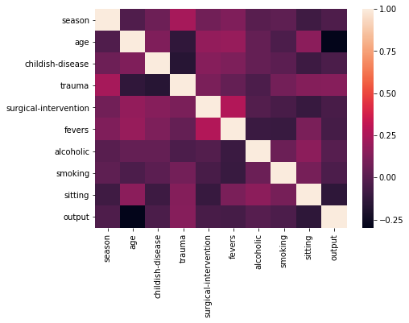

```python
corr=raw_data.apply(lambda x: x.factorize()[0]).corr()
fig=plt.figure(figsize=(7, 5))
fig=sns.heatmap(corr,
        xticklabels=corr.columns,
        yticklabels=corr.columns)

plt.savefig('corellation.png',bbox_inches = "tight")
```

The features are not corelated between themselfs so none of them has to be combined or removed

Exploring the distribution of the features including the output

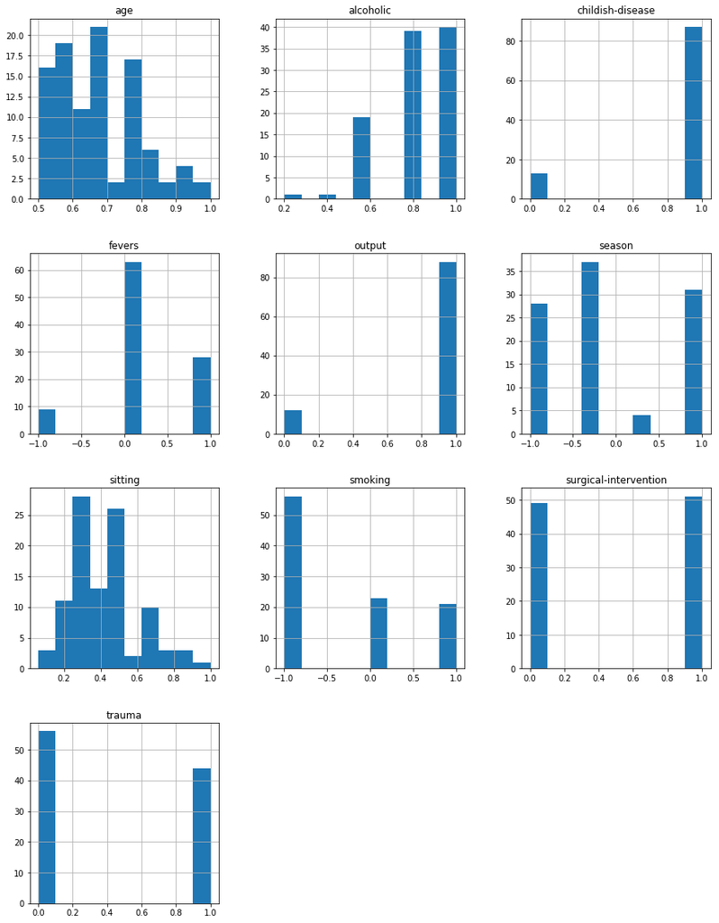

```python
temp_raw_data=raw_data.copy()
temp_raw_data['output']=temp_raw_data['output'].map({'O':0,'N':1})
fig = plt.figure(figsize = (15,20))
ax = fig.gca()
temp_raw_data.hist(ax = ax)
fig = ax.get_figure()
fig.savefig('hist.png')
```

I will create a copy and resample it but first change the output to numbers

```python
df=raw_data.copy()
df['output']=df['output'].map({'O':0,'N':1})
df.head()
```

|  | season | age | childish-disease | trauma | surgical-intervention | fevers | alcoholic | smoking | sitting | output |
| --- | --- | --- | --- | --- | --- | --- | --- | --- | --- | --- |
| 0 | -0.33 | 0.69 | 0 | 1 | 1 | 0 | 0.8 | 0 | 0.88 | 1 |
| 1 | -0.33 | 0.94 | 1 | 0 | 1 | 0 | 0.8 | 1 | 0.31 | 0 |
| 2 | -0.33 | 0.50 | 1 | 0 | 0 | 0 | 1.0 | -1 | 0.50 | 1 |
| 3 | -0.33 | 0.75 | 0 | 1 | 1 | 0 | 1.0 | -1 | 0.38 | 1 |
| 4 | -0.33 | 0.67 | 1 | 1 | 0 | 0 | 0.8 | -1 | 0.50 | 0 |

I want to resample the minory data only so I will split the Dataset

```python
df2=df.loc[df['output'] == 0]
df3=df.loc[df['output'] == 1]
```

Took inspiration from here https://gist.github.com/aflaxman/6871948 for bootstraping

```python
def bootstrap_resample(X, n=None):

    if isinstance(X, pd.Series):
        X = X.copy()
        X.index = range(len(X.index))
    if n == None:
        n = len(X)

    resample_i = np.floor(np.random.rand(n)*len(X)).astype(int)
    X_resample = np.array(X[resample_i])

    return X_resample
```

Resampling 3 times to get similar number of negative to positive observations

```python
for i in range(3):
    df_resampled = pd.DataFrame()
    for col in df2.columns:
        df_resampled[col] = bootstrap_resample(df2[col])
    df2=pd.concat([df2, df_resampled], ignore_index=True)
```

Lets see the new negative dataset size

```python
df2.shape
```

```
(96, 10)
```

Balancing it to same size as the positive df

```python
df2.drop(df2.tail(8).index,inplace=True)
```

Bringing the dataset back together and checking that it is balanced and aplying it to df

```python
df_resampled=pd.concat([df2, df3])
df_resampled.groupby('output').size()
```

```
output
0    88
1    88
dtype: int64
```

Saving the balanced dataset

```python
import datetime
mydate = datetime.datetime.now()
csvstr = datetime.datetime.strftime(mydate, '%d-%m-%Y,%H-%M')
df = df_resampled
df.head()
df.to_csv("df_resampled"+csvstr)
```

Dividing the data to training and testing

```python
train , test = train_test_split(df,test_size=0.2)
train_x = train.drop(columns=['output'],axis=1)
train_y = train['output']

test_x = test.drop(columns=['output'],axis=1)
test_y = test['output']
```

Selecting the best prediction model

```python
models=[RandomForestClassifier(),LogisticRegression(),svm.LinearSVC()]
models_names=['Random Forest','Logistic regression','SVM']
```

```python
from sklearn.metrics import classification_report
```

```python
for i in range(len(models)):
    model=models[i]
    model.fit(train_x,train_y)
    y_train_pred = model.predict(train_x)
    y_test_pred = model.predict(test_x)

    print("***********************************************")
    print(models_names[i])
    cm = confusion_matrix(test_y, y_test_pred)
    print ('confusion matrix:')
    print (cm)
    accuracy = accuracy_score(train_y, y_train_pred)
    print ('Accuracy_train:', accuracy)
    accuracy = accuracy_score(test_y, y_test_pred)
    print ('Accuracy_test:', accuracy)

    print(classification_report(train_y, y_train_pred))
```

```
Random Forest
confusion matrix:
[[18  1]
 [ 5 12]]
Accuracy_train: 0.9857142857142858
Accuracy_test: 0.8333333333333334
              precision    recall  f1-score   support

           0       0.99      0.99      0.99        69
           1       0.99      0.99      0.99        71

   micro avg       0.99      0.99      0.99       140
   macro avg       0.99      0.99      0.99       140
weighted avg       0.99      0.99      0.99       140

Logistic regression
confusion matrix:
[[13  6]
 [10  7]]
Accuracy_train: 0.7642857142857142
Accuracy_test: 0.5555555555555556
              precision    recall  f1-score   support

           0       0.78      0.72      0.75        69
           1       0.75      0.80      0.78        71

   micro avg       0.76      0.76      0.76       140
   macro avg       0.77      0.76      0.76       140
weighted avg       0.77      0.76      0.76       140

SVM
confusion matrix:
[[13  6]
 [10  7]]
Accuracy_train: 0.7785714285714286
Accuracy_test: 0.5555555555555556
              precision    recall  f1-score   support

           0       0.79      0.75      0.77        69
           1       0.77      0.80      0.79        71

   micro avg       0.78      0.78      0.78       140
   macro avg       0.78      0.78      0.78       140
weighted avg       0.78      0.78      0.78       140
```

The best model is Random Forest, now lets see if it can be improved

I searched for ways to improve Random Forest parameters and found this grate article , The code was taken from here: https://towardsdatascience.com/hyperparameter-tuning-the-random-forest-in-python-using-scikit-learn-28d2aa77dd74

```python
rf = RandomForestClassifier()
from pprint import pprint
# Look at parameters used by our current forest
print('Parameters currently in use:\n')
pprint(rf.get_params())
```

```
Parameters currently in use:

{'bootstrap': True,
 'class_weight': None,
 'criterion': 'gini',
 'max_depth': None,
 'max_features': 'auto',
 'max_leaf_nodes': None,
 'min_impurity_decrease': 0.0,
 'min_impurity_split': None,
 'min_samples_leaf': 1,
 'min_samples_split': 2,
 'min_weight_fraction_leaf': 0.0,
 'n_estimators': 'warn',
 'n_jobs': None,
 'oob_score': False,
 'random_state': None,
 'verbose': 0,
 'warm_start': False}
```

```python
from sklearn.model_selection import RandomizedSearchCV
# Number of trees in random forest
n_estimators = [int(x) for x in np.linspace(start = 200, stop = 2000, num = 10)]
# Number of features to consider at every split
max_features = ['auto', 'sqrt']
# Maximum number of levels in tree
max_depth = [int(x) for x in np.linspace(10, 110, num = 11)]
max_depth.append(None)
# Minimum number of samples required to split a node
min_samples_split = [2, 5, 10]
# Minimum number of samples required at each leaf node
min_samples_leaf = [1, 2, 4]
# Method of selecting samples for training each tree
bootstrap = [True, False]
# Create the random grid
random_grid = {'n_estimators': n_estimators,
               'max_features': max_features,
               'max_depth': max_depth,
               'min_samples_split': min_samples_split,
               'min_samples_leaf': min_samples_leaf,
               'bootstrap': bootstrap}
pprint(random_grid)
```

```
{'bootstrap': [True, False],
 'max_depth': [10, 20, 30, 40, 50, 60, 70, 80, 90, 100, 110, None],
 'max_features': ['auto', 'sqrt'],
 'min_samples_leaf': [1, 2, 4],
 'min_samples_split': [2, 5, 10],
 'n_estimators': [200, 400, 600, 800, 1000, 1200, 1400, 1600, 1800, 2000]}
```

```python
# Use the random grid to search for best hyperparameters
# First create the base model to tune
rf = RandomForestClassifier()
# Random search of parameters, using 3 fold cross validation,
# search across 100 different combinations, and use all available cores
rf_random = RandomizedSearchCV(estimator = rf, param_distributions = random_grid, n_iter = 100, cv = 3, verbose=2, random_state=42, n_jobs = -1)
# Fit the random search model
rf_random.fit(train_x,train_y)
```

```
Fitting 3 folds for each of 100 candidates, totalling 300 fits
```

```
[Parallel(n_jobs=-1)]: Using backend LokyBackend with 4 concurrent workers.
[Parallel(n_jobs=-1)]: Done  33 tasks      | elapsed:   19.7s
[Parallel(n_jobs=-1)]: Done 154 tasks      | elapsed:  1.0min
[Parallel(n_jobs=-1)]: Done 300 out of 300 | elapsed:  1.8min finished
```

```
RandomizedSearchCV(cv=3, error_score='raise-deprecating',
          estimator=RandomForestClassifier(bootstrap=True, class_weight=None, criterion='gini',
            max_depth=None, max_features='auto', max_leaf_nodes=None,
            min_impurity_decrease=0.0, min_impurity_split=None,
            min_samples_leaf=1, min_samples_split=2,
            min_weight_fraction_leaf=0.0, n_estimators='warn', n_jobs=None,
            oob_score=False, random_state=None, verbose=0,
            warm_start=False),
          fit_params=None, iid='warn', n_iter=100, n_jobs=-1,
          param_distributions={'n_estimators': [200, 400, 600, 800, 1000, 1200, 1400, 1600, 1800, 2000], 'max_features': ['auto', 'sqrt'], 'max_depth': [10, 20, 30, 40, 50, 60, 70, 80, 90, 100, 110, None], 'min_samples_split': [2, 5, 10], 'min_samples_leaf': [1, 2, 4], 'bootstrap': [True, False]},
          pre_dispatch='2*n_jobs', random_state=42, refit=True,
          return_train_score='warn', scoring=None, verbose=2)
```

```python
rf_random.best_params_
```

```
{'n_estimators': 1800,
 'min_samples_split': 2,
 'min_samples_leaf': 2,
 'max_features': 'auto',
 'max_depth': None,
 'bootstrap': True}
```

```python
rf =RandomForestClassifier()
```

```python
RFB=RandomForestClassifier(n_estimators = 1800,min_samples_split = 2,min_samples_leaf = 2)
RFB.fit(train_x,train_y)
```

```
RandomForestClassifier(bootstrap=True, class_weight=None, criterion='gini',
            max_depth=None, max_features='auto', max_leaf_nodes=None,
            min_impurity_decrease=0.0, min_impurity_split=None,
            min_samples_leaf=2, min_samples_split=2,
            min_weight_fraction_leaf=0.0, n_estimators=1800, n_jobs=None,
            oob_score=False, random_state=None, verbose=0,
            warm_start=False)
```

Lets compare the models

```python
models=[rf,RFB]
models_names=["Random Forest",'Random Forest-Best params']
for i in range(len(models)):
    model=models[i]
    model.fit(train_x,train_y)
    y_train_pred = model.predict(train_x)
    y_test_pred = model.predict(test_x)

    print("***********************************************")
    print(models_names[i])
    cm = confusion_matrix(test_y, y_test_pred)
    print ('confusion matrix:')
    print (cm)
    accuracy = accuracy_score(train_y, y_train_pred)
    print ('Accuracy_train:', accuracy)
    accuracy = accuracy_score(test_y, y_test_pred)
    print ('Accuracy_test:', accuracy)

    print(classification_report(train_y, y_train_pred))
```

```
Random Forest
confusion matrix:
[[18  1]
 [ 7 10]]
Accuracy_train: 0.9714285714285714
Accuracy_test: 0.7777777777777778
              precision    recall  f1-score   support

           0       0.96      0.99      0.97        69
           1       0.99      0.96      0.97        71

   micro avg       0.97      0.97      0.97       140
   macro avg       0.97      0.97      0.97       140
weighted avg       0.97      0.97      0.97       140

Random Forest-Best params
confusion matrix:
[[18  1]
 [ 4 13]]
Accuracy_train: 0.95
Accuracy_test: 0.8611111111111112
              precision    recall  f1-score   support

           0       0.96      0.94      0.95        69
           1       0.94      0.96      0.95        71

   micro avg       0.95      0.95      0.95       140
   macro avg       0.95      0.95      0.95       140
weighted avg       0.95      0.95      0.95       140
```

The best model is Random Forest, so lets asign over model to him

```python
model=RFB
```

pickeling

```python
with open('Fertility_RF_Classifier.pickle','wb') as f:
    pickle.dump(model, f)
```

```python
pickle_in = open('Fertility_RF_Classifier.pickle','rb')
model = pickle.load(pickle_in)
```

```python
df=df.drop(columns=['proba'],axis=1)
df.head()
```

|  | season | age | childish-disease | trauma | surgical-intervention | fevers | alcoholic | smoking | sitting | output |
| --- | --- | --- | --- | --- | --- | --- | --- | --- | --- | --- |
| 0 | -0.33 | 0.94 | 1 | 0 | 1 | 0 | 0.8 | 1 | 0.31 | 0 |
| 1 | -0.33 | 0.67 | 1 | 1 | 0 | 0 | 0.8 | -1 | 0.50 | 0 |
| 2 | 1.00 | 0.69 | 1 | 0 | 1 | 0 | 0.8 | -1 | 0.25 | 0 |
| 3 | 1.00 | 0.67 | 1 | 0 | 0 | 0 | 0.8 | 1 | 0.38 | 0 |
| 4 | 1.00 | 0.69 | 1 | 0 | 1 | -1 | 1.0 | -1 | 0.44 | 0 |

Calculating the probability for Normal since it will give more meaningfull plots and adding it to the data

```python
data_for_proba=df.drop(columns=['output'],axis=1)
#data_for_proba.head()
proba=model.predict_proba(data_for_proba)
df['proba']=proba[:,1]
df.head()
```

|  | season | age | childish-disease | trauma | surgical-intervention | fevers | alcoholic | smoking | sitting | output | proba |
| --- | --- | --- | --- | --- | --- | --- | --- | --- | --- | --- | --- |
| 0 | -0.33 | 0.94 | 1 | 0 | 1 | 0 | 0.8 | 1 | 0.31 | 0 | 0.431934 |
| 1 | -0.33 | 0.67 | 1 | 1 | 0 | 0 | 0.8 | -1 | 0.50 | 0 | 0.354303 |
| 2 | 1.00 | 0.69 | 1 | 0 | 1 | 0 | 0.8 | -1 | 0.25 | 0 | 0.481815 |
| 3 | 1.00 | 0.67 | 1 | 0 | 0 | 0 | 0.8 | 1 | 0.38 | 0 | 0.089192 |
| 4 | 1.00 | 0.69 | 1 | 0 | 1 | -1 | 1.0 | -1 | 0.44 | 0 | 0.088484 |

I got the dataset normalized, I am undoing the normalization for cclearer data view

```python
df2=df.copy()
df2['age']=df['age']*36
df2['sitting']=df['sitting']*16
df2['childish-disease']=df['childish-disease'].map({0:1,1:0})
df2['trauma']=df['trauma'].map({0:1,1:0})
df2['surgical-intervention']=df['surgical-intervention'].map({0:1,1:0})
df2['fevers']=df['fevers'].map({-1:1,0:0,1:-1})
df2['alcoholic']=df['alcoholic'].map({0.2:1,0.4:0.8,0.6:0.6,0.8:0.4,1:0.2})
df2['season']=df['season'].map({-1:"Winter",-0.33:"Spring",0.33:"Summer",1:"Fall"})
df2.head()
```

|  | season | age | childish-disease | trauma | surgical-intervention | fevers | alcoholic | smoking | sitting | output | proba |
| --- | --- | --- | --- | --- | --- | --- | --- | --- | --- | --- | --- |
| 0 | Spring | 33.84 | 0 | 1 | 0 | 0 | 0.4 | 1 | 4.96 | 0 | 0.431934 |
| 1 | Spring | 24.12 | 0 | 0 | 1 | 0 | 0.4 | -1 | 8.00 | 0 | 0.354303 |
| 2 | Fall | 24.84 | 0 | 1 | 0 | 0 | 0.4 | -1 | 4.00 | 0 | 0.481815 |
| 3 | Fall | 24.12 | 0 | 1 | 1 | 0 | 0.4 | 1 | 6.08 | 0 | 0.089192 |
| 4 | Fall | 24.84 | 0 | 1 | 0 | 1 | 0.2 | -1 | 7.04 | 0 | 0.088484 |

Visualization of the dataset

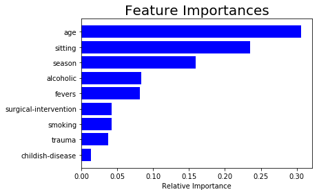

```python
features=data_for_proba.columns
importances = model.feature_importances_
indices = np.argsort(importances)

fig = plt.figure(1)
plt.title('Feature Importances', fontsize=20)
fig=plt.barh(range(len(indices)), importances[indices], color='b', align='center')
plt.yticks(range(len(indices)), features[indices])
plt.xlabel('Relative Importance')




plt.savefig('feature.png',bbox_inches = "tight")
```

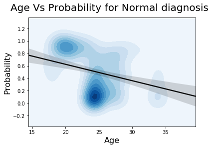

```python
fig = sns.kdeplot(df2.age, df2.proba,cmap="Blues", shade=True)
fig = sns.regplot(df2.age, df2.proba, scatter=False,color = 'black')
plt.xlabel('Age', fontsize=16)
plt.ylabel('Probability', fontsize=16)
plt.suptitle('Age Vs Probability for Normal diagnosis', fontsize=20)
plt.savefig('Age vs Proba.png',bbox_inches = "tight")
```

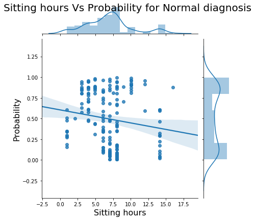

```python
fig=sns.jointplot(df2.sitting, df2.proba, kind="reg")
plt.xlabel('Sitting hours', fontsize=16)
plt.ylabel('Probability', fontsize=16)
plt.suptitle('Sitting hours Vs Probability for Normal diagnosis', fontsize=20)
plt.savefig('Seat vs Proba.png',bbox_inches = "tight")
```

```
p-value annotation legend:
ns: 5.00e-02 < p <= 1.00e+00
*: 1.00e-02 < p <= 5.00e-02
**: 1.00e-03 < p <= 1.00e-02
***: 1.00e-04 < p <= 1.00e-03
****: p <= 1.00e-04

Fall v.s. Winter: t-test independent samples, P_val=9.989e-13 stat=-8.043e+00
Winter v.s. Summer: t-test independent samples, P_val=4.351e-05 stat=4.633e+00
Spring v.s. Winter: t-test independent samples, P_val=2.080e-04 stat=-3.877e+00
Spring v.s. Summer: t-test independent samples, P_val=3.598e-02 stat=2.145e+00
```

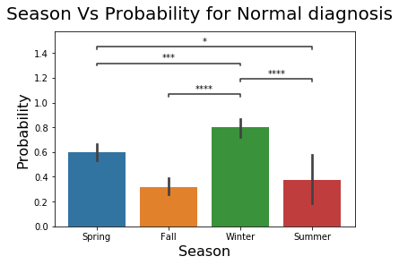

```python
order = ['Spring','Fall', 'Winter', 'Summer']
ax=sns.barplot(x="season", y="proba", data=df2)
add_stat_annotation(ax, data=df2, x="season", y="proba",order=order,
                    box_pairs=[("Winter", "Fall"),("Winter", "Summer"),("Winter", "Spring"),("Summer", "Spring")],
                    test='t-test_ind', text_format='star',  verbose=2)
plt.xlabel('Season', fontsize=16)
plt.ylabel('Probability', fontsize=16)
plt.suptitle('Season Vs Probability for Normal diagnosis', fontsize=20)
#add_stat_annotation(ax,data=df2, x="season", y="proba", test='t-test_ind')


plt.savefig('Season vs Proba.png',bbox_inches = "tight")
```

```
p-value annotation legend:
ns: 5.00e-02 < p <= 1.00e+00
*: 1.00e-02 < p <= 5.00e-02
**: 1.00e-03 < p <= 1.00e-02
***: 1.00e-04 < p <= 1.00e-03
****: p <= 1.00e-04

0 v.s. 1: t-test independent samples, P_val=nan stat=nan
```

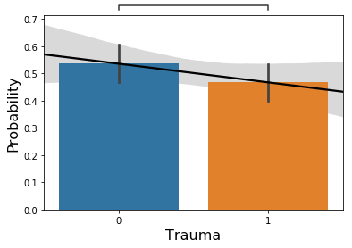

```python
order = ['0', '1']
ax=sns.barplot(x="trauma", y="proba", data=df2)
ax=sns.regplot(df2.trauma, df2.proba, scatter=False,color = 'black')
add_stat_annotation(ax, data=df2, x="trauma", y="proba",order=order,box_pairs=[('0', '1')],test='t-test_ind', text_format='star',  verbose=2,loc='outside')

plt.xlabel('Trauma', fontsize=16)
plt.ylabel('Probability', fontsize=16)
#plt.suptitle('Trauma  Vs Probability for Normal diagnosis', fontsize=20)
plt.savefig('Trauma vs Proba.png',bbox_inches = "tight")
```

```
p-value annotation legend:
ns: 5.00e-02 < p <= 1.00e+00
*: 1.00e-02 < p <= 5.00e-02
**: 1.00e-03 < p <= 1.00e-02
***: 1.00e-04 < p <= 1.00e-03
****: p <= 1.00e-04

-1 v.s. 0: t-test independent samples, P_val=nan stat=nan
-1 v.s. 1: t-test independent samples, P_val=nan stat=nan
```

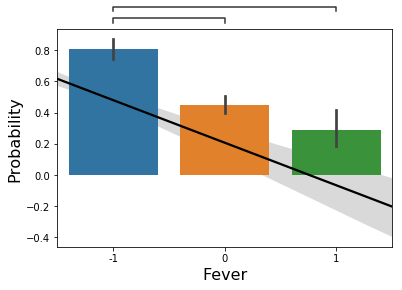

```python
order = ["-1", "0", "1"]
ax=sns.barplot(x="fevers", y="proba", data=df2)
ax=sns.regplot(df2.fevers, df2.proba, scatter=False,color = 'black')
add_stat_annotation(ax, data=df2, x="season", y="proba",order=order,box_pairs=[("-1", "1"),("-1","0")],test='t-test_ind', text_format='star',  verbose=2,loc='outside')

plt.xlabel('Fever', fontsize=16)
plt.ylabel('Probability', fontsize=16)
#plt.suptitle('Fever  Vs Probability for Normal diagnosis', fontsize=20)
plt.savefig('Fever vs Proba.png',bbox_inches = "tight")
```

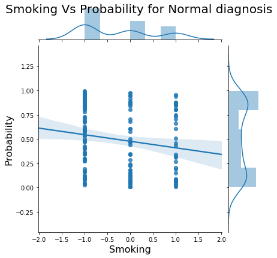

```python
sns.jointplot(df2.smoking, df2.proba, kind="reg")
plt.xlabel('Smoking', fontsize=16)
plt.ylabel('Probability', fontsize=16)
plt.suptitle('Smoking Vs Probability for Normal diagnosis', fontsize=20)
plt.savefig('Smoking vs Proba.png',bbox_inches = "tight")
```

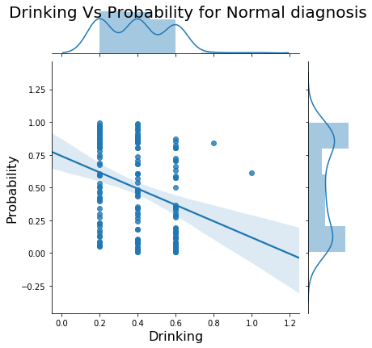

```python
sns.jointplot(df2.alcoholic, df2.proba, kind="reg")
plt.xlabel('Drinking', fontsize=16)
plt.ylabel('Probability', fontsize=16)
plt.suptitle('Drinking Vs Probability for Normal diagnosis', fontsize=20)
plt.savefig('Drinking vs Proba.png',bbox_inches = "tight")
```

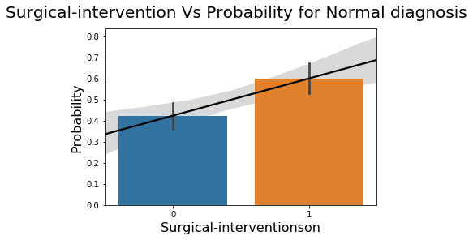

```python
order = ['0', '1']




ax=sns.barplot(x="surgical-intervention", y="proba", data=df2)
ax=sns.regplot(df2['surgical-intervention'], df2.proba, scatter=False,color = 'black')
#add_stat_annotation(ax, data=df2, x="surgical-intervention", y="proba",order=order,box_pairs=[('0', '1')],test='t-test_ind', text_format='star',  verbose=2,loc='outside')
plt.xlabel('Surgical-interventionson', fontsize=16)
plt.ylabel('Probability', fontsize=16)

plt.suptitle('Surgical-intervention Vs Probability for Normal diagnosis', fontsize=20)
plt.savefig('Surgical vs Proba.png',bbox_inches = "tight")
```

[output not shown]

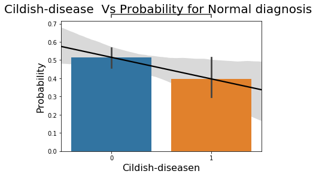

```python
order = ['0', '1']
ax=sns.barplot(x="childish-disease", y="proba", data=df2)
ax=sns.regplot(df2['childish-disease'], df2.proba, scatter=False,color = 'black')
add_stat_annotation(ax, data=df2, x="childish-disease", y="proba",order=order,box_pairs=[('0', '1')],test='t-test_ind', text_format='star',  verbose=2,loc='outside')
plt.xlabel('Cildish-diseasen', fontsize=16)
plt.ylabel('Probability', fontsize=16)
plt.suptitle('Cildish-disease  Vs Probability for Normal diagnosis', fontsize=20)
plt.savefig('Childish vs Proba.png',bbox_inches = "tight")
```

```python
df2["Smoker"] = df2['smoking'] > -1
```

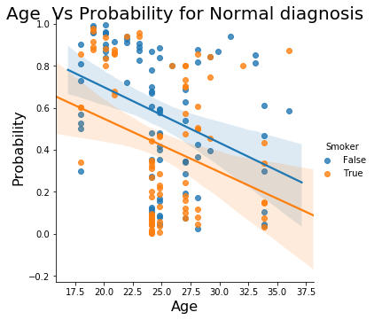

```python
sns.lmplot(x="age", y="proba", hue="Smoker", data=df2)
plt.xlabel('Age', fontsize=16)
plt.ylabel('Probability', fontsize=16)
plt.suptitle('Age  Vs Probability for Normal diagnosis', fontsize=20)
plt.savefig('Age with smoke vs Proba.png',bbox_inches = "tight")
```

```python
df2["Drinks"] = df2['alcoholic'] > 0.2
```

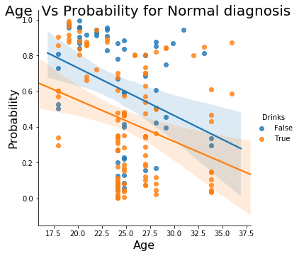

```python
sns.lmplot(x="age", y="proba", hue="Drinks", data=df2);
plt.xlabel('Age', fontsize=16)
plt.ylabel('Probability', fontsize=16)
plt.suptitle('Age  Vs Probability for Normal diagnosis', fontsize=20)
plt.savefig('Age with drink vs Proba.png',bbox_inches = "tight")
```